# Simple Data Analysis and Linear and Nonlinear Classification: The Red and White Wine datasets

We want to predict whether a given wine sample corresponds to a red or white wine.

The datasets are available in two separate csv files at https://www.kaggle.com/sgus1318/winedata

### Attribute Information:

Patterns have 12 numeric features.

1. fixed acidity
2. volatile acidity
3. citric acid
4. residual sugar
5. chlorides
6. free sulfur dioxide
7. total sulfur dioxide
8. density
9. pH
10. sulphates
11. alcohol
12. quality

To these we must add a 0-1 label where the positive class (1) corresponds to the smaller red wine sample.

### Instrucciones para la entrega final

**Seguid cuidadosamente las siguientes pautas:**

1. Crear un directorio de nombre vuestro apellido.
2. Situar en él:
   - Un archivo `apellido_afi_2019.ipynb` con vuestro notebook completo y otro archivo `apellido_afi_2019.html` con una versión html
   - Un archivo `wine.csv` con un csv donde se junten las features de los datos red and white del problema.
3. Situar también en él un pdf `apellido.pdf` con vuestro nombre y las respuestas al cuestionario.
4. Comprimir el **directorio** a un archivo `apellido.zip` o `apellido.7z` que será lo que se entregue
5. El notebook debe ejecutarse de inicio a final antes de la entrega.

Para cualquier duda,consultar con el profesor (jose.dorronsoro@uam.es)

```python
%matplotlib inline
```

```python
import os
import sys
import time
import pickle
import gzip

import numpy as np
import matplotlib.pyplot as plt
import pandas as pd

import seaborn as sns

np.set_printoptions(precision=3)

import warnings
warnings.filterwarnings('ignore')
```

## Loading Data

```python
red_wine= pd.read_csv('./entrega/winedata/winequality_red.csv')
white_wine= pd.read_csv('./entrega/winedata/winequality_white.csv')
red_wine['type']=1 # 1:red wine
white_wine['type']=0 # 0:white wine
wine= red_wine.append(white_wine)
```

## Data Exploration

Perform here descriptive statistics, boxplots and positive and negative class histograms

### Descriptive Statistics

and etc ...!!!

```python
print( "num_rows: %d\tnum_columns: %d\n" % (wine.shape[0], wine.shape[1]) )
print( "num_rows_red: %d\tnum_rows_white: %d\nIt is NOT an unbalanced data set\n" % (wine[wine.type==1].shape[0], wine[wine.type==0].shape[0]) )
print( "Column names:\n", list(wine.columns))

vars_wine   = list(wine.columns[ : -1])
target_wine = wine.columns[-1]
```

```
num_rows: 6497	num_columns: 13

num_rows_red: 1599	num_rows_white: 4898
It is NOT an unbalanced data set

Column names:
 ['fixed acidity', 'volatile acidity', 'citric acid', 'residual sugar', 'chlorides', 'free sulfur dioxide', 'total sulfur dioxide', 'density', 'pH', 'sulphates', 'alcohol', 'quality', 'type']
```

```python
wine.describe(include='all').T
```

|  | count | mean | std | min | 25% | 50% | 75% | max |
| --- | --- | --- | --- | --- | --- | --- | --- | --- |
| fixed acidity | 6497.0 | 7.215307 | 1.296434 | 3.80000 | 6.40000 | 7.00000 | 7.70000 | 15.90000 |
| volatile acidity | 6497.0 | 0.339666 | 0.164636 | 0.08000 | 0.23000 | 0.29000 | 0.40000 | 1.58000 |
| citric acid | 6497.0 | 0.318633 | 0.145318 | 0.00000 | 0.25000 | 0.31000 | 0.39000 | 1.66000 |
| residual sugar | 6497.0 | 5.443235 | 4.757804 | 0.60000 | 1.80000 | 3.00000 | 8.10000 | 65.80000 |
| chlorides | 6497.0 | 0.056034 | 0.035034 | 0.00900 | 0.03800 | 0.04700 | 0.06500 | 0.61100 |
| free sulfur dioxide | 6497.0 | 30.525319 | 17.749400 | 1.00000 | 17.00000 | 29.00000 | 41.00000 | 289.00000 |
| total sulfur dioxide | 6497.0 | 115.744574 | 56.521855 | 6.00000 | 77.00000 | 118.00000 | 156.00000 | 440.00000 |
| density | 6497.0 | 0.994697 | 0.002999 | 0.98711 | 0.99234 | 0.99489 | 0.99699 | 1.03898 |
| pH | 6497.0 | 3.218501 | 0.160787 | 2.72000 | 3.11000 | 3.21000 | 3.32000 | 4.01000 |
| sulphates | 6497.0 | 0.531268 | 0.148806 | 0.22000 | 0.43000 | 0.51000 | 0.60000 | 2.00000 |
| alcohol | 6497.0 | 10.491801 | 1.192712 | 8.00000 | 9.50000 | 10.30000 | 11.30000 | 14.90000 |
| quality | 6497.0 | 5.818378 | 0.873255 | 3.00000 | 5.00000 | 6.00000 | 6.00000 | 9.00000 |
| type | 6497.0 | 0.246114 | 0.430779 | 0.00000 | 0.00000 | 0.00000 | 0.00000 | 1.00000 |

Feature boxplots

Se observa que que no ninguna feature tiene mucha variabilidad (altura de la caja no grande, lo que implica que el 50% de los datos están concentrados, en este caso entorno al cero tras haber normalizado) y casi todas tienen muchos outliers.

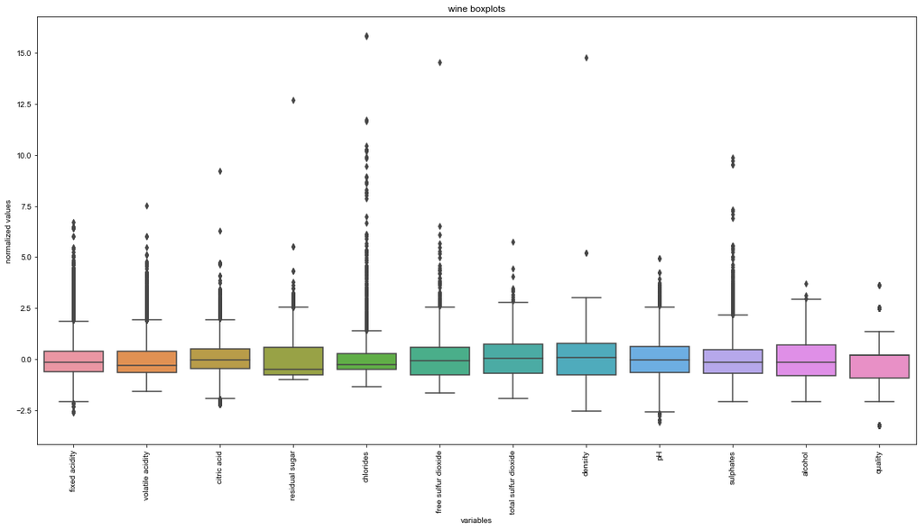

```python
##########

wine_normalizado = (wine - wine.mean()) / wine.std() #normalizar para tener rangos uniformes en histogramas

plt.figure( figsize=(20, 10))
plt.title("wine boxplots")
sns.set_style("white")
bx_plot = sns.boxplot(data=wine_normalizado.drop('type',axis=1))
plt.xticks(rotation=90)
plt.xlabel("variables")
plt.ylabel("normalized values")
plt.show()
```

### Histograms and scatterplots

Del análisis de los histogramas, se observa que no hay ninguna variable que en 1-dim (diagonal) se separé bien entre vino tinto y vino blanco.  
En 2-dim (fuera de la diagonal) tampoco se aprecia bien que haya una línea de separación entre los dos labels.

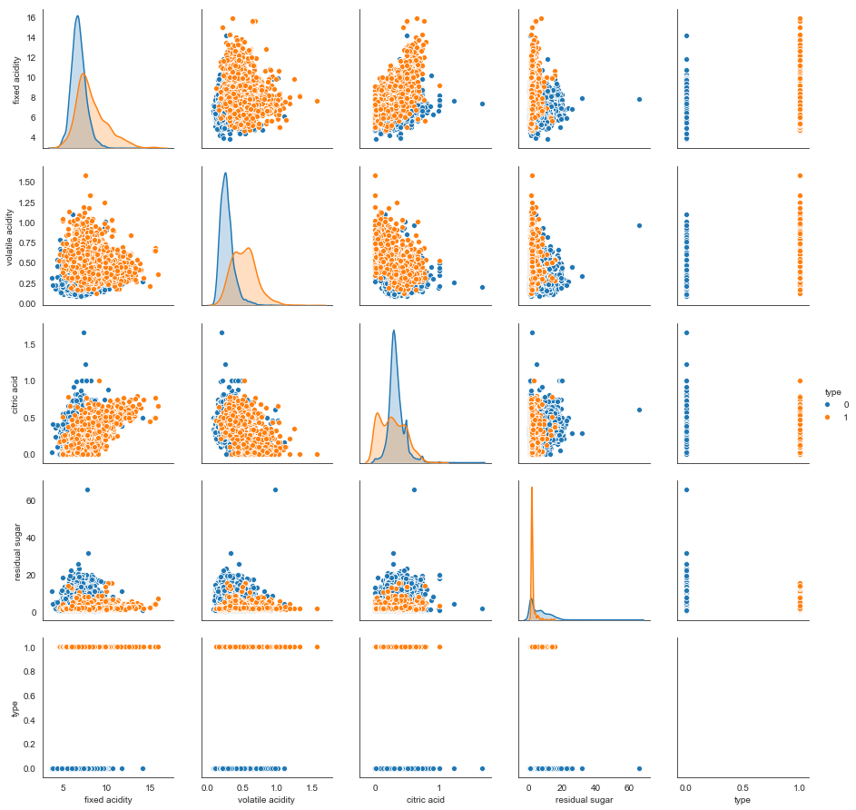

```python
########## feature histograms over the entire sample
pair_plot = sns.pairplot(wine[vars_wine[:4] + [target_wine]], hue='type', diag_kind='kde')
plt.show()
```

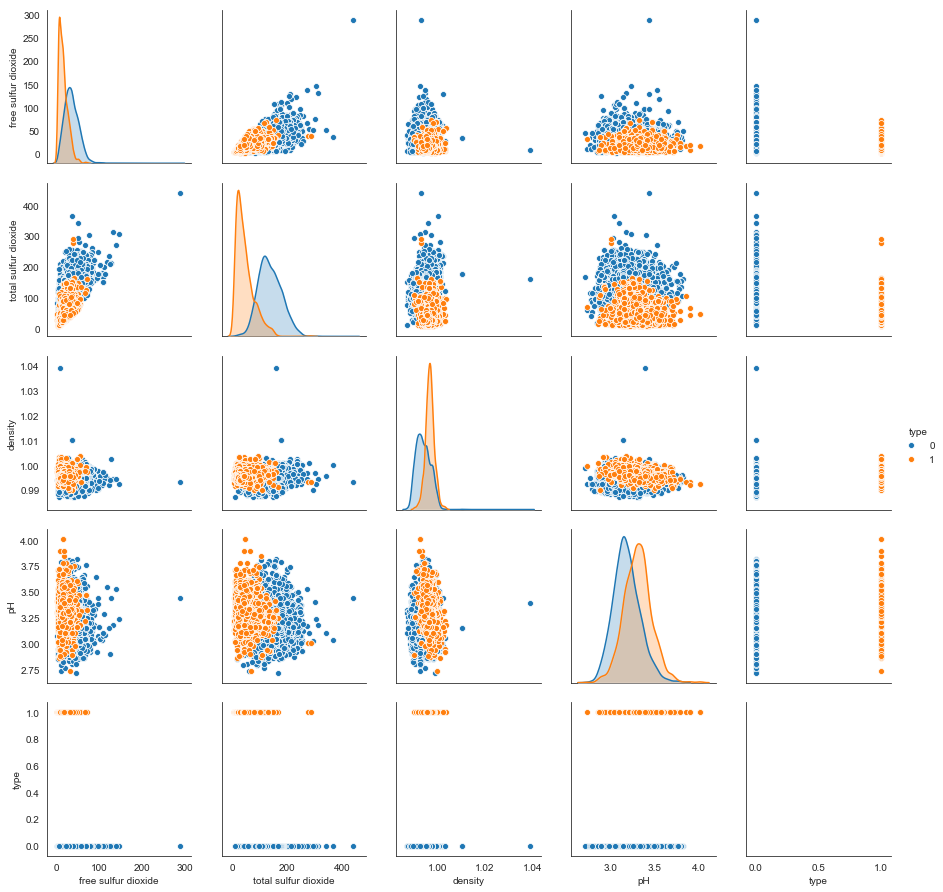

```python
pair_plot = sns.pairplot(wine[vars_wine[5:9] + [target_wine]], hue='type', diag_kind='kde')
plt.show()
```

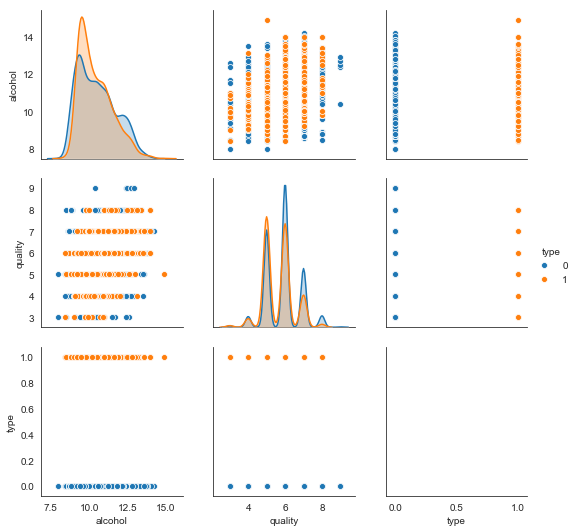

```python
pair_plot = sns.pairplot(wine[vars_wine[10:] + [target_wine]], hue='type', diag_kind='kde')
plt.show()
```

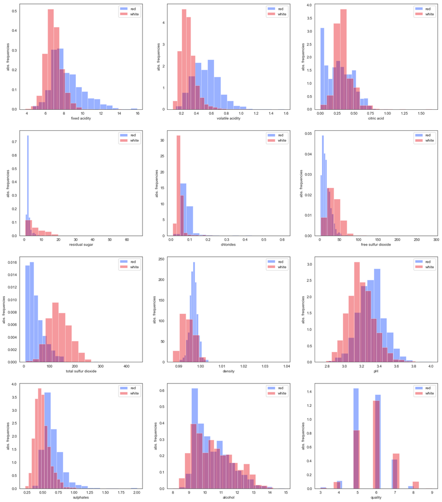

```python
# But it's better to have the positive and negative histograms together

#sns.set(color_codes=True)
sns.set_color_codes("bright")
sns.set_style("white")

num_columns = 3
num_rows = int( np.ceil( len(wine.columns)/num_columns ) )
bins = 17

plt.figure( figsize=(20, 6*num_rows))
plt.title("red wine vs white wine")

for i, var in enumerate (wine[vars_wine].columns):
    pos = np.where( wine[target_wine] == 1)[0]
    neg = np.where( wine[target_wine] == 0)[0]

    ax = plt.subplot(num_rows, num_columns, i+1)
    #ax.set_title(var)

    sns.distplot(wine[var].iloc[pos], bins=bins, norm_hist=True, kde=False, color='b', label='red')
    sns.distplot(wine[var].iloc[neg], bins=bins, norm_hist=True, kde=False, color='r', label='white')

    plt.ylabel("abs. frequencies")
    plt.legend(loc='best')

plt.show()
```

Matrz de correlaciones

```python
wineCorr= wine.corr().round(decimals=3)
```

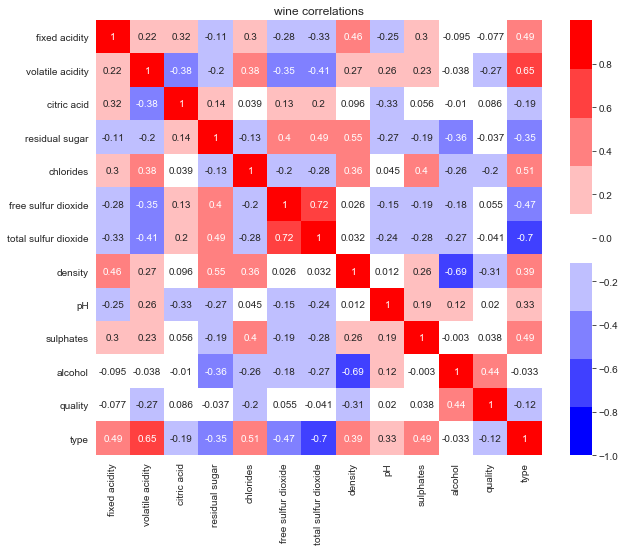

```python
# correlation heatmap
n_colors = 9
cMap = plt.cm.get_cmap("bwr",lut=n_colors )

plt.figure( figsize=(10, 8))
plt.title('wine correlations')

h_map = sns.heatmap(wineCorr.values, vmin=-1., vmax=1., cmap=cMap,
                    annot=True,
                    xticklabels=list(wine.columns),
                    yticklabels=list(wine.columns))

cbar = h_map.collections[0].colorbar
l_ticks = [k/10. for k in range(-10, 10, 2)]
cbar.set_ticks(l_ticks)

plt.show()
```

Varibales explicativas más correlacionadas con la target

```python
########## rank features according to correlation with targets
label_corr= wine.corr()['type'].abs().round(3).sort_values(ascending=False).T
print( label_corr)
```

```
type                    1.000
total sulfur dioxide    0.700
volatile acidity        0.653
chlorides               0.513
sulphates               0.487
fixed acidity           0.487
free sulfur dioxide     0.472
density                 0.391
residual sugar          0.349
pH                      0.329
citric acid             0.187
quality                 0.119
alcohol                 0.033
Name: type, dtype: float64
```

```python
X= wine[vars_wine]
y= wine[target_wine]
```

### Simple Model Fitting

Explore here the application of a Logistic Regression Model.

```python
from sklearn.preprocessing import MinMaxScaler
from sklearn.preprocessing import StandardScaler
from sklearn.linear_model import LogisticRegression
from sklearn.pipeline import Pipeline

# split data set in features: x and label: y.
X= wine.drop('type',axis=1)
y= wine.loc[:,'type']

# scaler normalized + lr pipeline
mm_sc = MinMaxScaler()
std_sc = StandardScaler()
lr_obj = LogisticRegression(penalty= "l2", dual=True, verbose=False, multi_class='ovr')

pipeline = Pipeline(steps=[('std_sc', std_sc), # ('mm_sc', mm_sc)
                           ('lr', lr_obj)])

lr= pipeline.named_steps['lr']
t_0 = time.time()

# Tuning
from sklearn.model_selection import StratifiedKFold
from sklearn.model_selection import GridSearchCV

# paramGrid
lr_C = [10.**k for k in np.linspace(start=0, stop=3, num=11)]
param_grid ={'lr__C': lr_C}
print("num_hyperparams", len(lr_C))

# Cross-Validation split
n_folds = 10
skf = StratifiedKFold(n_folds, shuffle=True)

# Set the performance metric, scoring
scorer = 'recall'

# gridSearch
search = GridSearchCV(pipeline,
                      param_grid=param_grid,
                      cv=skf,
                      scoring=scorer,
                      n_jobs=2,
                      return_train_score=True)

model_lr = search.fit(X, y)
print("search_time:", round(time.time()-t_0,2))
```

```
num_hyperparams 11
search_time: 11.47
```

Save the gridSearch

```python
file_pkl = open("c_cv_search_wine.plk", 'wb')
pickle.dump(model_lr, file_pkl)
file_pkl.close()
```

Load the gridSearch

```python
file_pkl = open("c_cv_search_wine.plk", 'rb')
model_lr = pickle.load(file_pkl)
file_pkl.close()
```

Take a look at the hyperparamters obtained

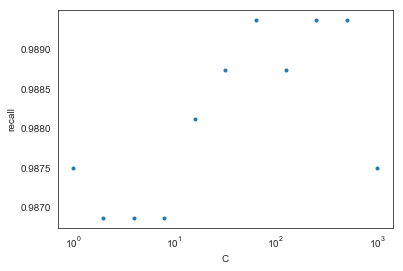

```python
df_model_lr = pd.DataFrame.from_dict(model_lr.cv_results_)
lr_C = [10.**k for k in np.linspace(start=0, stop=3, num=11)]

plt.xlabel('C')
plt.ylabel('recall')
plt.xscale('log')
_ = plt.plot( df_model_lr['param_lr__C'], df_model_lr['mean_test_score'], '.')
plt.show()
```

Prediction value

```python
pred= search.predict(X)
```

Best params

```python
bestModel= search.best_estimator_
print("best_C:", search.best_params_['lr__C'])
```

```
best_C: 63.0957344480193
```

Performance

Accuracy, recall and precision of best model

```python
from sklearn.model_selection import cross_validate
```

```python
# Set the performance metric, scoring
scorer = ('accuracy','recall','precision')
scores= cross_validate(bestModel, X,y, scoring= scorer, return_train_score=True, verbose= False, return_estimator = True)
print("\nTRAIN\nTrain score accuracy: %.4f\nTrain score recall: %.4f\nTrain score precision: %.4f" % (scores['train_accuracy'].mean(), scores['train_recall'].mean(), scores['train_precision'].mean()))
print("\nTEST\nTest score accuracy: %.4f\nTest score recall: %.4f\nTest score precision: %.4f" % (scores['test_accuracy'].mean(), scores['test_recall'].mean(), scores['test_precision'].mean()))
```

```
TRAIN
Train score accuracy: 0.9950
Train score recall: 0.9881
Train score precision: 0.9915

TEST
Test score accuracy: 0.9945
Test score recall: 0.9894
Test score precision: 0.9882
```

### Conclusions on the Data

Write here your first conclusions on the data and the original problem

Prediction plot based on wine type.

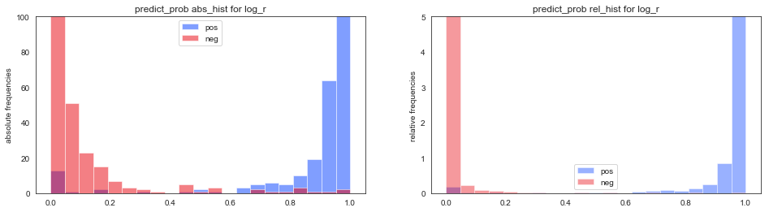

```python
pred= search.predict_proba(X)
pos = np.where(y == 1)[0]
neg = np.where(y == 0)[0]

bins = 21

plt.figure(figsize=(16, 4))

# first log_r
plt.subplot(1, 2, 1)
plt.title("predict_prob abs_hist for log_r")
plt.ylabel("absolute frequencies")
plt.ylim(0., 100.)
plt.hist( pred[pos, 1], bins=bins, density=False, color='b', label='pos', alpha=0.5)
plt.hist( pred[neg, 1], bins=bins, density=False, color='r', label='neg', alpha=0.5)
plt.legend(loc='best')

plt.subplot(1, 2, 2)
plt.title("predict_prob rel_hist for log_r")
plt.ylabel("relative frequencies")
plt.ylim(0., 5.)
sns.distplot( pred[pos, 1], bins=bins, norm_hist=True, kde=False, color='b', label='pos')
sns.distplot( pred[neg, 1], bins=bins, norm_hist=True, kde=False, color='r', label='neg')
plt.legend(loc='best')

plt.show()
```

### A More Difficult Problem

Choose according to the previous analysis five (5) of the original features and remove them with the goal of making the red-white classification problem as difficult as you can.

Explain your variable choices in a clear and principled way.

### Metodología

1. Correlación en 1-dim de las features con label.
2. Error de Bayes de las features en 1-dim.
3. Coeficientes de la *LogisticRegression.*
4. Métrica *importance* en RandomForest.

### 1. Correlación en 1-dim de las features con label.

Se listan los 5 features con mayor correlación con label en 1-dim y se plotean todas.

```python
label_corr[1:6]
```

```
total sulfur dioxide    0.700
volatile acidity        0.653
chlorides               0.513
sulphates               0.487
fixed acidity           0.487
Name: type, dtype: float64
```

```python
varsToRemove= pd.DataFrame({'corr_1d': list(label_corr.index)[1:6]})
```

```
No handles with labels found to put in legend.
```

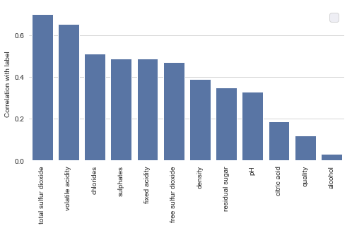

```python
label_corr=(wine.corr()['type'].abs().round(3).sort_values(ascending=False).T)
wineCorrPlot= pd.DataFrame(label_corr).drop('type',axis=0)
with sns.axes_style("whitegrid", {'axes.grid' : True}):
    fig, ax = plt.subplots(1,1, figsize=(8,4))

sns.set(font_scale=1.5)
ax.spines["top"].set_visible(False)
ax.spines["bottom"].set_visible(False)
ax.spines["right"].set_visible(False)
ax.spines["left"].set_visible(False)
sns.barplot(x = list(wineCorrPlot.index), y = 'type', data=wineCorrPlot, color='b')
plt.xticks(rotation=90)
plt.ylabel("Correlation with label")
plt.legend(loc='best')
```

### 2. Error de Bayes de las features en 1-dim.

Se obtiene para cada feature la diagonal False de la matriz de confusión (True False y Negative False) para el modelo logistic regression con dicha variable.

```python
from sklearn.preprocessing import StandardScaler
from sklearn.linear_model import LogisticRegression
from sklearn.metrics import confusion_matrix
def BayesErr(df, feature, label):
    # preprocessing
    X_lr = df.loc[:,feature].values.reshape(-1,1)
    y = df[label].values
    # scale data
    std_sc = StandardScaler()
    x = std_sc.fit_transform(X_lr)
    # modelling -logisticRegression- (Default regularization value is C=1)
    lr =  LogisticRegression(solver='lbfgs', penalty='l2', max_iter=1000)
    lr.fit(x, y)
    y_pred= lr.predict(x)
    # confussion matrix
    cm= confusion_matrix(y, y_pred, labels=(0,1))
    # Bayes error
    return (cm[0][1]+cm[1][0])/len(wine)
```

```python
BayesError= {feature: BayesErr(wine, feature, 'type')
 for feature in vars_wine
}
#feature_list= sorted([(feature,err) for feature,err in BayesError.items()], key=lambda item: item[1])
feature_df= pd.DataFrame([(feature,err) for feature,err in BayesError.items()], columns=['feature','bayes_err']).sort_values(by='bayes_err', ascending=False).reset_index().drop('index',axis=1)
varsToRemove['BayesError']= feature_df.loc[:5,'feature']
feature_df.loc[:5,]
```

|  | feature | bayes_err |
| --- | --- | --- |
| 0 | density | 0.264738 |
| 1 | citric acid | 0.246114 |
| 2 | residual sugar | 0.246114 |
| 3 | alcohol | 0.246114 |
| 4 | quality | 0.246114 |
| 5 | pH | 0.244421 |

```
No handles with labels found to put in legend.
```

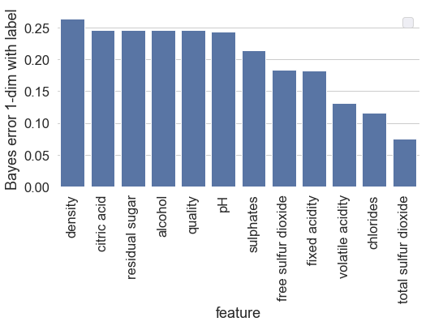

```python
with sns.axes_style("whitegrid", {'axes.grid' : True}):
    fig, ax = plt.subplots(1,1, figsize=(8,4))

sns.set(font_scale=1.5)
ax.spines["top"].set_visible(False)
ax.spines["bottom"].set_visible(False)
ax.spines["right"].set_visible(False)
ax.spines["left"].set_visible(False)
sns.barplot(x='feature', y='bayes_err', data=feature_df, color='b')
plt.xticks(rotation=90)
plt.ylabel("Bayes error 1-dim with label")
plt.legend(loc='best')
```

### 3. Coeficientes de la *LogisticRegression.*

```python
# split data set in features: x and label: y.
X= wine.drop('type',axis=1)
y= wine.loc[:,'type']

# scale data
std_sc = StandardScaler()
x = std_sc.fit_transform(X)
# modelling -logisticRegression- (C=best_params)
lr_obj = LogisticRegression(C= search.best_params_['lr__C'],penalty= "l2", dual=True, verbose=False, multi_class='ovr')
_= lr_obj.fit(x,y)
```

```
No handles with labels found to put in legend.
```

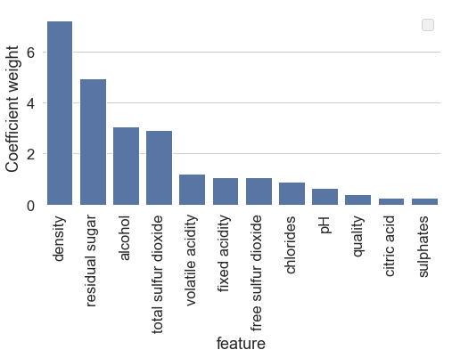

```python
lr_coef= {element[0]:round(element[1],4)
          for element in zip(X.columns,abs(lr_obj.coef_).tolist()[0])
         }
lr_coefPlot= pd.DataFrame.from_dict(lr_coef, orient='index').reset_index()
lr_coefPlot.columns=['feature','coeff']
lr_coefPlot.sort_values(by='coeff', ascending=False, inplace=True)
with sns.axes_style("whitegrid", {'axes.grid' : True}):
    fig, ax = plt.subplots(1,1, figsize=(8,4))

sns.set(font_scale=1.5)
ax.spines["top"].set_visible(False)
ax.spines["bottom"].set_visible(False)
ax.spines["right"].set_visible(False)
ax.spines["left"].set_visible(False)
sns.barplot(x = 'feature', y = 'coeff', data=lr_coefPlot, color='b')
plt.xticks(rotation=90)
plt.ylabel("Coefficient weight")
plt.legend(loc='best')
```

```python
lr_coef= {element[0]:round(element[1],4)
          for element in zip(X.columns,abs(lr_obj.coef_).tolist()[0])
         }
```

```python
varsToRemove['lr_coefs']= list(lr_coefPlot['feature'][:5])
```

### 4. Métrica *importance* en RandomForest.

Para confirmar las variables más relevantes se opta por un úlitmo modelo, RandomForest, obteniendo las variables más relevantes mediante el atributo `importance` del modelo que rankiniza las festures en función del número de veces que aparacen para realizar el corte y en qué nivel del árbol.

```python
from sklearn.ensemble import RandomForestClassifier
# split data set in features: x and label: y.
X= wine.drop('type',axis=1)
y= wine.loc[:,'type']

# scale data
std_sc = StandardScaler()
x = std_sc.fit_transform(X)

# modelling -RandomForestClassifier-
RF = RandomForestClassifier()
param_grid = {
    "max_depth": [2, 4, 16], #LÍMITE VERTICAL DEL ARBOL
    "max_features": ["sqrt"], # Selección del método para tomar el número de variables randomly
    "min_samples_split": [2, 4, 8], # si el corte deja <min_samples_split no permite la pregunta
    "min_samples_leaf":[1, 2, 4, 8], # la hoja se queda cuando <= min_samples_leaf
    "bootstrap": [True, False], # LÍMITE HORIZONTAL DEL ARBOL >> Cuando se llega a número de hojas =max_leaf_nodes
    "criterion": ["gini", "entropy"]
}

# Cross-Validation split
n_folds = 3
skf = StratifiedKFold(n_folds, shuffle=True)

# Set the performance metric, scoring
scorer = 'accuracy'

# gridSearch
searchRF = GridSearchCV(RF,
                      param_grid=param_grid,
                      cv=skf,
                      scoring=scorer,
                      n_jobs=2)

modelRF = searchRF.fit(X, y)
```

```python
file_pkl = open("rf_search_wine.plk", 'wb')
pickle.dump(modelRF, file_pkl)
file_pkl.close()
```

```python
modelRF.best_estimator_
```

```
RandomForestClassifier(bootstrap=False, class_weight=None,
            criterion='entropy', max_depth=16, max_features='sqrt',
            max_leaf_nodes=None, min_impurity_decrease=0.0,
            min_impurity_split=None, min_samples_leaf=1,
            min_samples_split=2, min_weight_fraction_leaf=0.0,
            n_estimators=10, n_jobs=None, oob_score=False,
            random_state=None, verbose=0, warm_start=False)
```

```python
modelRF.best_params_
```

```
{'bootstrap': False,
 'criterion': 'entropy',
 'max_depth': 16,
 'max_features': 'sqrt',
 'min_samples_leaf': 1,
 'min_samples_split': 2}
```

```python
RF.set_params(**modelRF.best_params_)
RF.fit(X,y)
importancyFeature= pd.DataFrame({'feature': X.columns, 'importancy': RF.feature_importances_})
importancyFeature.sort_values(by='importancy',ascending=False, inplace=True)
importancyFeature.iloc[:5,:]
```

|  | feature | importancy |
| --- | --- | --- |
| 6 | total sulfur dioxide | 0.341051 |
| 4 | chlorides | 0.223580 |
| 1 | volatile acidity | 0.133042 |
| 3 | residual sugar | 0.066086 |
| 7 | density | 0.061670 |

```python
varsToRemove['rf_importancy']= list(importancyFeature.iloc[:5,0])
```

Selección de variables a eliminar

A la vista de la tabla resumen *varsToRemove*, se opta por eliminar:

total sulfur dioxide

volatile acidity

density

Donde factor con mayor peso es el error de Bayes. El resto confirma en parte sus variables.

```python
varsToRemove
```

|  | corr_1d | BayesError | lr_coefs | rf_importancy |
| --- | --- | --- | --- | --- |
| 0 | total sulfur dioxide | density | density | total sulfur dioxide |
| 1 | volatile acidity | citric acid | residual sugar | chlorides |
| 2 | chlorides | residual sugar | alcohol | volatile acidity |
| 3 | sulphates | alcohol | total sulfur dioxide | residual sugar |
| 4 | fixed acidity | quality | volatile acidity | density |

Las variables que se eliminan por ser las más relevantes son:

`density`: por aparecer en la lr y Bayes error

`residual sugar`: por aparecer en la lr y Bayes error

`total sulfur dioxide`: por aparecer en la lr y tener la mayor correlación con el label en 1-dim además de aparaecer en el RF.

`alcohol`: por aparecer en la lr y Bayes error

`volatile acidity`: por aparecer en la lr y tener mucha correlación con el label en 1-dim además de aparaecer en el RF.

```python
X_wine= wine[vars_wine]
y_wine= wine[target_wine]

def reduce_dataset(dataset):
    return dataset.drop(labels=['density','residual sugar','total sulfur dioxide','alcohol','volatile acidity'],axis=1)

list_datasets= [X_wine, wine]
X, wine_reduced= [reduce_dataset(dataset) for dataset in list_datasets]
y= y_wine

vars_wine_red = list(wine_reduced.columns[:-1])
target_wine_red = wine_reduced.columns[-1]
num_patterns, dim = X.shape
```

## MLP Modeling and Performance Estimation

Define a strategy based on nested CV searches in order to estimate as realistically as possible the performance of a MLP classifier.

In order that the execution times remain manageable, you must choose first a reasonabe MLP architecture and use **three** (3)-fold inner GridSearchCV for the parameter `alpha` (over a scaler + MLP classifier pipeline) and outer (over a best GridSearchCV estimator) using here the `cross_validate` function over the `recall` and `precision` metrics.

If needed, follow the guidelines in https://scikit-learn.org/stable/modules/cross_validation.html

**Important**: here we do not want to get a unique optimal `alpha` parameter but to estimate the `recall` and `precision` performance as precisely and cleanly as possible.

Se realiza un primer modelado con optimizando el hiperparámetro `alpha`.  
Los parámetros para MLP classifier son:

solver='adam' es el solver más rentable.

activation='relu' para que no haya problemas en el backpropagation con las derivadas cercanas a cero.

shuffle='true' porque no hay orden establecido en el dataset.

early_stopping='False' para agotar el número máximo de iteraciones. Esto se hace porque el tiempo de computación en este caso no es importante debido al tamaño del dataset.

hidden_layer_sizes=(100,) es la que viene por defecto. 1 capa de 100 núcleos. No debe dar problemas de overfitting al tener más de 6k observaciones.

Función gridSearch

```python
from sklearn.preprocessing import MinMaxScaler
from sklearn.svm import SVC
from sklearn.neural_network import MLPClassifier
from sklearn.pipeline import Pipeline
from sklearn.model_selection import StratifiedKFold
from sklearn.model_selection import GridSearchCV
from functools import reduce
```

```python
t_0= time.time()

# normalized
scaller = StandardScaler()

# model
modelObj = MLPClassifier(solver='adam',
                         activation='relu',
                         tol=1.e-4,
                         warm_start=False,
                         shuffle=True,
                         max_iter=500,
                         early_stopping=False)
# pipeline
pipeline = Pipeline(steps=[('std_sc', scaller),
                           ('mlp', modelObj)])
# paramGrid
mlp__alpha = [10.**k for k in range(-5, 6)]

param_grid ={
             'mlp__alpha': mlp__alpha
            }

# Cross-Validation split
n_folds = 3
crossValidation = StratifiedKFold(n_folds, shuffle=True)

# Set the performance metric, scoring
scorer = ['recall','precision','f1','accuracy']

# gridSearch
search = GridSearchCV(pipeline,
                         param_grid=param_grid,
                         cv=crossValidation,
                         scoring=scorer,
                         n_jobs=2,
                         refit=scorer[0],
                         return_train_score=True,
                         verbose=True)

print("Number of combinations", reduce((lambda x, y: x * y), [len(param_grid[key]) for key in param_grid]) )
# model train
mlpTuning_1 = search.fit(X, y)
print("search_time:", round(time.time()-t_0,2))
mlpPipeline_1= pipeline
```

```
Number of combinations 11
Fitting 3 folds for each of 11 candidates, totalling 33 fits
```

```
[Parallel(n_jobs=2)]: Using backend LokyBackend with 2 concurrent workers.
[Parallel(n_jobs=2)]: Done  33 out of  33 | elapsed:   57.9s finished
```

```
search_time: 68.74
```

Se comprueba que el modelo ha encontrado el mínimo en la función de pérdida.  
Sino se extiende el número de iteraciones para intentar lograrlo.  
Si extendiéndolo hasta un número razonable de iteraciones no se consguiera llegar al mínimo, tendríamos que saber que la solución no es la óptima.

```
No handles with labels found to put in legend.
```

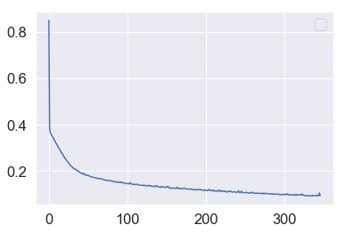

```python
modelObj.set_params(**{key.replace('mlp__',''): value for key, value in mlpTuning_1.best_params_.items()})
model= modelObj.fit(X,y)
_= plt.plot(model.loss_curve_)
plt.legend(loc='best')
```

Guardamos el resultado del gridSearch en un dataFrame

```python
df_mlpTuning = pd.DataFrame.from_dict(mlpTuning_1.cv_results_)
```

**Best params**:

1. for recall metric
2. for precision metric

1. Recall metric

```python
df_mlpTuning.iloc[df_mlpTuning['mean_test_recall'].idxmax()][['param_mlp__alpha']]
```

```
param_mlp__alpha    1e-05
Name: 0, dtype: object
```

2. Precission metric

```python
df_mlpTuning.iloc[df_mlpTuning['mean_test_precision'].idxmax()][['param_mlp__alpha']]
```

```
param_mlp__alpha    0.001
Name: 2, dtype: object
```

Save the gridSearch (para no tener que volver a entrenar el gridSearch y cerramos el kernel)

```python
file_pkl = open("mlp_search_wine_reduced.plk", 'wb')
pickle.dump(mlpTuning_1, file_pkl)
file_pkl.close()
```

Load the gridSearch (por si se ha cerrado el kernel, partimos de este punto)

```python
file_pkl = open("mlp_search_wine_reduced.plk", 'rb')
mlpTuning_1 = pickle.load(file_pkl)
file_pkl.close()
```

## Analyzing best hyperpars

### 1. Sort by best performance metric *recall*.

Plot de la relación del hiperparámetro con las métricas de performance

```python
df_mlpTuning.sort_values(by='mean_test_recall', ascending=False, inplace=True)
df_mlpTuning.reset_index(drop=True, inplace=True)
```

```
performance metric: RECALL
best alpha: 0.000010
Recall: 0.960performance metric: PRECISION
best alpha: 0.001000
Precision: 0.970
```

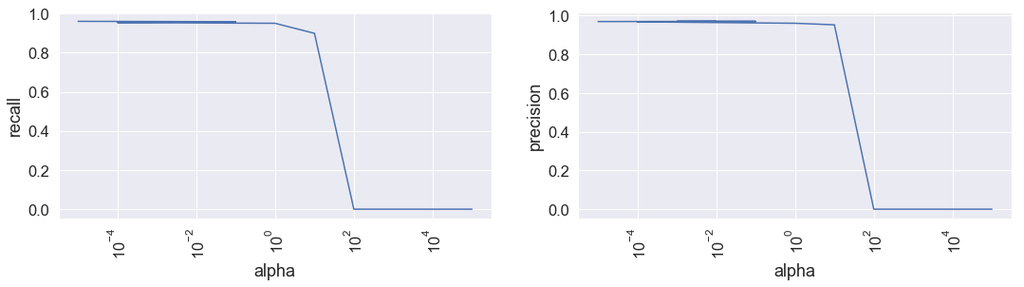

```python
import matplotlib.pyplot as plt
from matplotlib.ticker import FuncFormatter, MaxNLocator

print("performance metric: RECALL\nbest alpha: %f\nRecall: %.3f" \
      "performance metric: PRECISION\nbest alpha: %f\nPrecision: %.3f" %\
      (df_mlpTuning.iloc[df_mlpTuning['mean_test_recall'].idxmax()]['param_mlp__alpha'],
       df_mlpTuning.iloc[df_mlpTuning['mean_test_recall'].idxmax()]['mean_test_recall'],
       df_mlpTuning.iloc[df_mlpTuning['mean_test_precision'].idxmax()]['param_mlp__alpha'],
       df_mlpTuning.iloc[df_mlpTuning['mean_test_precision'].idxmax()]['mean_test_precision']
      ))

plt.figure(figsize=(18, 4))

plt.subplot(1, 2, 1)
plt.xlabel('alpha')
plt.ylabel('recall')
plt.xticks(rotation=90)
plt.xscale('log', basex=10)
_ = plt.plot( df_mlpTuning['param_mlp__alpha'], df_mlpTuning['mean_test_recall'])

plt.subplot(1, 2, 2)
plt.xlabel('alpha')
plt.ylabel('precision')
plt.xticks(range(len(mlp__alpha)), mlp__alpha, rotation=90)
plt.xscale('log', basex=10)
_ = plt.plot( df_mlpTuning['param_mlp__alpha'], df_mlpTuning['mean_test_precision'])

plt.show()
```

### 2º Tuning

```python
t_0= time.time()

# normalized
scaller = StandardScaler()

# model
modelObj = MLPClassifier(solver='adam',
                         activation='relu',
                         tol=1.e-4,
                         warm_start=False,
                         shuffle=True,
                         max_iter=500,
                         early_stopping=True)
# pipeline
pipeline = Pipeline(steps=[('std_sc', scaller),
                           ('mlp', modelObj)])
# paramGrid
mlp__alpha = [2.**k for k in np.linspace(start=-10, stop=0, num=10)]

param_grid ={
             'mlp__alpha': mlp__alpha
            }

# Cross-Validation split
n_folds = 3
crossValidation = StratifiedKFold(n_folds, shuffle=True)

# Set the performance metric, scoring
scorer = ['recall','precision','f1','accuracy']

# gridSearch
search = GridSearchCV(pipeline,
                         param_grid=param_grid,
                         cv=crossValidation,
                         scoring=scorer,
                         n_jobs=2,
                         refit=scorer[0],
                         return_train_score=False,
                         verbose=True)

print("Number of combinations", reduce((lambda x, y: x * y), [len(param_grid[key]) for key in param_grid]) )
# model train
mlpTuning_2 = search.fit(X, y)
print("search_time:", round(time.time()-t_0,2))
mlpPipeline_2= pipeline
```

```
Number of combinations 10
Fitting 3 folds for each of 10 candidates, totalling 30 fits
```

```
[Parallel(n_jobs=2)]: Using backend LokyBackend with 2 concurrent workers.
[Parallel(n_jobs=2)]: Done  30 out of  30 | elapsed:    7.3s finished
```

```
search_time: 8.24
```

```
No handles with labels found to put in legend.
```

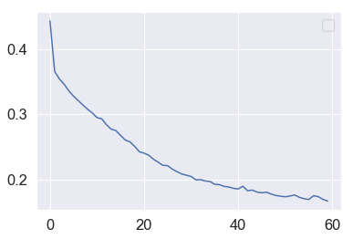

```python
modelObj.set_params(**{key.replace('mlp__',''): value for key, value in mlpTuning_2.best_params_.items()})
model= modelObj.fit(X,y)
_= plt.plot(model.loss_curve_)
plt.legend(loc='best')
```

```python
df_mlpTuning = pd.DataFrame.from_dict(mlpTuning_2.cv_results_)
```

```
Performance metric: RECALL
best alpha: 0.009843
Recall: 0.951

Performance metric: PRECISION
best alpha: 0.462937
Precision: 0.962
```

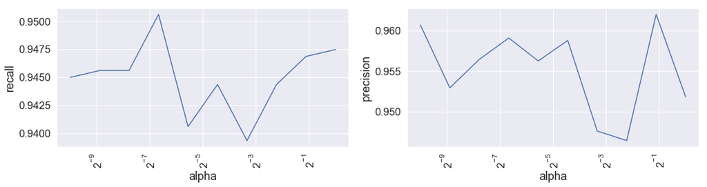

```python
import matplotlib.pyplot as plt
from matplotlib.ticker import FuncFormatter, MaxNLocator

print("Performance metric: RECALL\nbest alpha: %f\nRecall: %.3f\n\nPerformance metric: PRECISION\nbest alpha: %f\nPrecision: %.3f" %\
      (df_mlpTuning.iloc[df_mlpTuning['mean_test_recall'].idxmax()]['param_mlp__alpha'],
       df_mlpTuning.iloc[df_mlpTuning['mean_test_recall'].idxmax()]['mean_test_recall'],
       df_mlpTuning.iloc[df_mlpTuning['mean_test_precision'].idxmax()]['param_mlp__alpha'],
       df_mlpTuning.iloc[df_mlpTuning['mean_test_precision'].idxmax()]['mean_test_precision']
      ))

plt.figure(figsize=(18, 4))

plt.subplot(1, 2, 1)
plt.xlabel('alpha')
plt.ylabel('recall')
plt.xticks(rotation=90)
plt.xscale('log', basex=2)
_ = plt.plot( df_mlpTuning['param_mlp__alpha'], df_mlpTuning['mean_test_recall'])

plt.subplot(1, 2, 2)
plt.xlabel('alpha')
plt.ylabel('precision')
plt.xticks(range(len(mlp__alpha)), mlp__alpha, rotation=90)
plt.xscale('log', basex=2)
_ = plt.plot( df_mlpTuning['param_mlp__alpha'], df_mlpTuning['mean_test_precision'])

plt.show()
```

**Best params**:

1. for recall metric
2. for precision metric

1. Recall metric

```python
df_mlpTuning.iloc[df_mlpTuning['mean_test_recall'].idxmax()][['param_mlp__alpha']]
```

```
param_mlp__alpha    0.00984313
Name: 3, dtype: object
```

2. Precission metric

```python
df_mlpTuning.iloc[df_mlpTuning['mean_test_precision'].idxmax()][['param_mlp__alpha']]
```

```
param_mlp__alpha    0.462937
Name: 8, dtype: object
```

### Cálculo de las métricas de performance

Se aplica la función cross_validate de sklearn para calcular el performance en el test.  
Esta función trabaja diviendo el dataset en k folds. En cada iteración reserva un fold para el test, siendo el train el resto de folds (k-1). Entrenando el modelo en el train y obtiene el performance el test.  
La ventaja de esta función es que no dividimos previamente el dataset en train/test un única vez sino tantas como folds definamos. Por tanto, da una variabilidad al análisis que de la forma tradicional no se obitiene al trabajar únicamente con una iteración.

```python
# for performance metric recall:
import re

print("Best model: \nbest alpha: %f\n" % \
      (df_mlpTuning.iloc[df_mlpTuning['mean_test_recall'].idxmax()]['param_mlp__alpha']))
scores_list=[]
for metric in scorer:
    r = re.compile(".*mlp")
    param_list = list(filter(r.match, list(mlpTuning_2.cv_results_.keys())))
    modelObj.set_params(**{param.replace('param_mlp__',''): df_mlpTuning.iloc[df_mlpTuning['mean_test_'+metric].idxmax()][param] for param in param_list})

    scores= cross_validate(mlpPipeline_2, X,y, scoring= metric, return_train_score=True, verbose= False)
    scores_list.append(scores['test_score'].mean())
    print(str(metric).upper(),"\nTrain:  %.3f\tTest: %.3f\n" % (scores['train_score'].mean(), scores['test_score'].mean()))
```

```
Best model:
best alpha: 0.009843

RECALL
Train:  0.950	Test: 0.934

PRECISION
Train:  0.942	Test: 0.938

F1
Train:  0.946	Test: 0.936

ACCURACY
Train:  0.978	Test: 0.972
```

```python
scores_df= pd.DataFrame.from_dict({"mlpTuning_2":scores_list})
```

```python
# for performance metric recall:
import re
for metric in scorer:
    r = re.compile(".*mlp")
    param_list = list(filter(r.match, list(mlpTuning_2.cv_results_.keys())))
    modelObj.set_params(**{param.replace('param_mlp__',''): df_mlpTuning.iloc[df_mlpTuning['mean_test_'+metric].idxmax()][param] for param in param_list})

    scores= cross_validate(mlpPipeline_2, X,y, scoring= metric, return_train_score=True, verbose= False)
    print(str(metric).upper(),"\nTrain:  %.3f\tTest: %.3f\n" % (scores['train_score'].mean(), scores['test_score'].mean()))
```

```
RECALL
Train:  0.945	Test: 0.934

PRECISION
Train:  0.961	Test: 0.953

F1
Train:  0.947	Test: 0.937

ACCURACY
Train:  0.977	Test: 0.970
```

Por último, se comprueba gráficamente el performance mediante el histograma de la distriución de las probabilidades.

En la gráfica de frecuencias realtivas se aprecia que el error de Bayes es pequeño como cabe esperar para valores del performance entorno al 95%.  
La predicción se realiza sobre el mismo `training set` con la función *cros_val_predict* ya que el *cross_validate* solo calcula performance y no da predicciones.  
Por tanto, y aunque en este caso no se realice, sería conveniente realizar un split en train/test antes del entrenamiento y posterior predicción para evitar que el aprendizaje de las observaciones del test por parte del modelo.  
En este caso como no se realiza el split, el resultado muestra el máximo performance que implica el mínimo error. Mínimo error inherente al propio dataset, es decir, el **error de Bayes**.

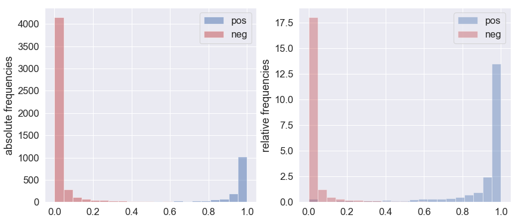

```python
######### plot prob histograms
from sklearn.model_selection import cross_val_predict
y_pred_proba = cross_val_predict(mlpPipeline_2, X,y, cv=3, method='predict_proba')
pos= np.where(y == 1)[0]
neg= np.where(y == 0)[0]

bins = 21

plt.figure(figsize=(14, 6))

plt.subplot(1, 2, 1)
plt.ylabel("absolute frequencies")
plt.hist( y_pred_proba[pos, 1], bins=bins, density=False, color='b', label='pos', alpha=0.5)
plt.hist( y_pred_proba[neg, 1], bins=bins, density=False, color='r', label='neg', alpha=0.5)
plt.legend(loc='best')

plt.subplot(1, 2, 2)
plt.ylabel("relative frequencies")
sns.distplot( y_pred_proba[pos, 1], bins=bins, norm_hist=True, kde=False, color='b', label='pos')
sns.distplot( y_pred_proba[neg, 1], bins=bins, norm_hist=True, kde=False, color='r', label='neg')
plt.legend(loc='best')

plt.show()
```

# Análisis de los pesos de la red neuronal.

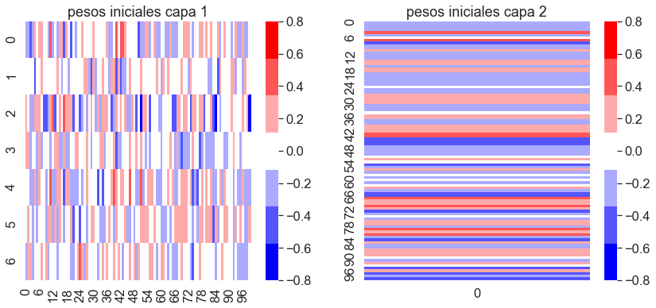

```python
cMap = plt.cm.get_cmap("bwr",lut=7)
plt.figure( figsize=(14, 6))

plt.subplot(1, 2, 1)
plt.title("pesos iniciales capa 1")
h_map_0 = sns.heatmap(mlpTuning_2.best_estimator_.named_steps['mlp'].coefs_[0], vmin=-0.8, vmax=0.8, cmap=cMap)
cbar = h_map_0.collections[0].colorbar
l_ticks = [k/10. for k in range(-8, 9, 2)]
cbar.set_ticks(l_ticks)

plt.subplot(1, 2, 2)
plt.title("pesos iniciales capa 2")
h_map_1 = sns.heatmap(mlpTuning_2.best_estimator_.named_steps['mlp'].coefs_[1], vmin=-0.8, vmax=0.8, cmap=cMap)
cbar = h_map_1.collections[0].colorbar
l_ticks = [k/10. for k in range(-8, 9, 2)]
cbar.set_ticks(l_ticks)


plt.show()
```